# Saving Visualizations

# Goal

This notebook shows how to save a `ggplot` with a chosen file type, size, and resolution.

File-writing code is disabled here, so the module renders without creating extra files. Run those chunks manually when you want to save files.

# File Saving Considerations

When you export a plot, you are deciding:

- file format
- width and height, which combine to make an aspect ratio
- resolution
- background
- whether the output is for a notebook, slides, a paper, or the web

# Build A Plot

| Data preparation step | Functions in this chunk |
| --- | --- |
| Keep or remove rows | `slice_max()` |
| Create or change columns | `mutate()` |

| Plot component | Code in this chunk |
| --- | --- |
| Aesthetic mappings | `x`; `y` |
| Geoms / stats | `geom_col()` |
| `geom_col()` properties | `fill` |
| Scales / coordinates / facets / labels | `coord_flip()`; `scale_y_continuous()`; `labs()`; `theme_minimal()` |

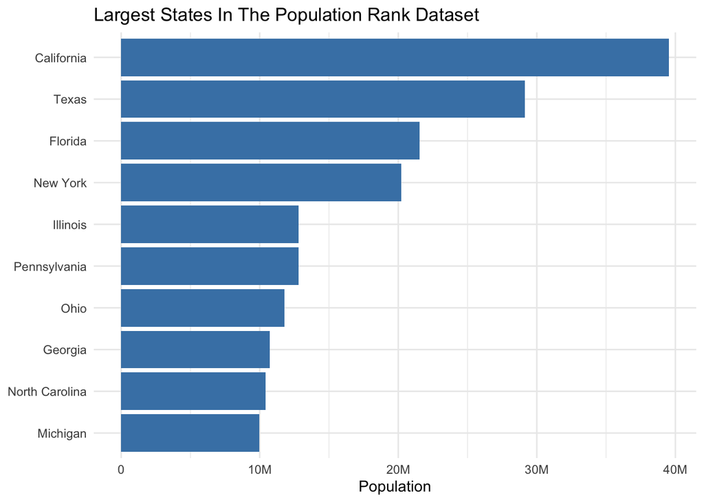

```r
states <- readr::read_csv("data/real/state_population_ranks.csv")
top_states <- states |>
  slice_max(population, n = 10) |>
  mutate(state_name = reorder(state_name, population))

p1 <- ggplot(top_states, aes(x = state_name, y = population)) +
  geom_col(fill = "steelblue") +
  coord_flip() +
  scale_y_continuous(labels = scales::label_number(scale_cut = scales::cut_short_scale())) +
  labs(
    title = "Largest States In The Population Rank Dataset",
    x = NULL,
    y = "Population"
  ) +
  theme_minimal()

p1
```

# Save With `ggsave()`

The main `ggplot2` function for saving plots is `ggsave()`.

These chunks are not evaluated when rendering. They use `practice/work/`, which is the student workspace for files created during class.

```r
ggsave(
  filename = "practice/work/top-states.png",
  plot = p1,
  width = 7,
  height = 5,
  dpi = 300,
  bg = "white"
)
```

# Common Formats

Use formats based on where the plot is going.

| Format | Common Use |
| --- | --- |
| PNG | slides, websites, documents |
| PDF | manuscripts, vector graphics, print workflows |
| SVG | web graphics that need to scale with device size |

Do not use raster/bitmap formats like JPEG; they are almost never the right choice for saving a data visualization.

# Save Several Versions

```r
ggsave("practice/work/top-states.png", p1, width = 7, height = 5, dpi = 300, bg = "white")
ggsave("practice/work/top-states.pdf", p1, width = 7, height = 5)
ggsave("practice/work/top-states.svg", p1, width = 7, height = 5)
```

Use `bg = "white"` for PNG files when the plot might be placed on a slide or webpage with an unknown background. Without a background, the objects in the figure may clash or have difficult being seen on a dark background.

DPI controls pixel density; it matters for png files. Higher DPIs have more pixel density but will be larger.

# Size Is A Design Element

A plot that is readable in one place can become unreadable somewhere else. Size is not just an export setting; it changes how the plot feels and how easily the reader can scan it.

In Quarto, use chunk options such as `fig-width` and `fig-height` to control the size of a rendered figure in a notebook or HTML page. By default, Quartuo uses inches.

# Aspect Ratio

Perhaps the most important decisions is the aspect ratio: how wide the figure is vs. how tall it is. Consider where the figure will be used/published.

Sensible defaults:

- 16:9 for slides / dashboards / web embeds (e.g., width = 10, height = 5.625)
- 4:3 for reports / papers / Quarto pages (e.g., width = 8, height = 6)
- 3:2 often works well (e.g., width = 9, height = 6)

It is not a coincidence the above aspect ratio are common sizes for screens on laptops and TVs. They work well. Using the same aspect ratios make your figures fit well on thoes mediums, especially when the figure is show as a block element (i.e., no wrapping text, nothing around it).

# Too Small

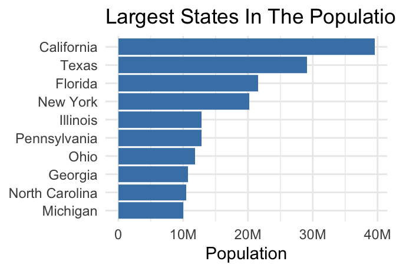

```r
p1
```

# Too Big

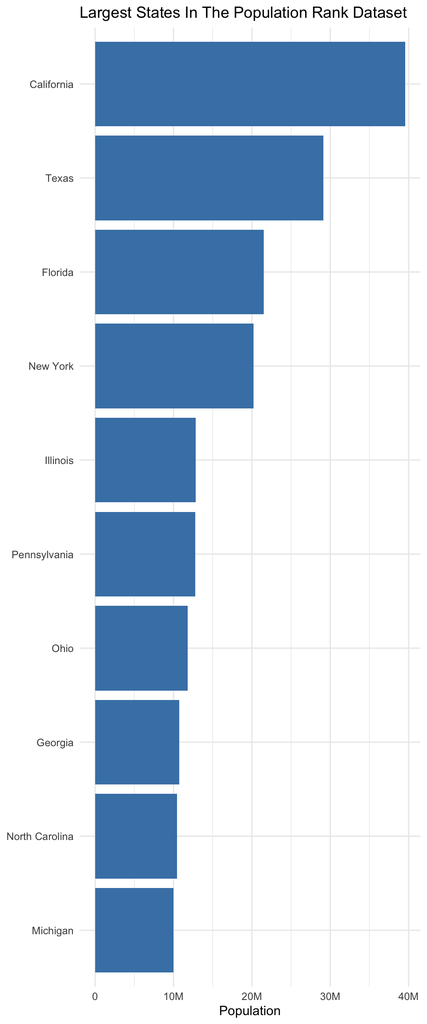

```r
p1
```

# Just Right

Here we use a 4:3 ratio, or 8:6 inches.

| Plot component | Code in this chunk |
| --- | --- |
| Scales / coordinates / facets / labels | `theme()` |

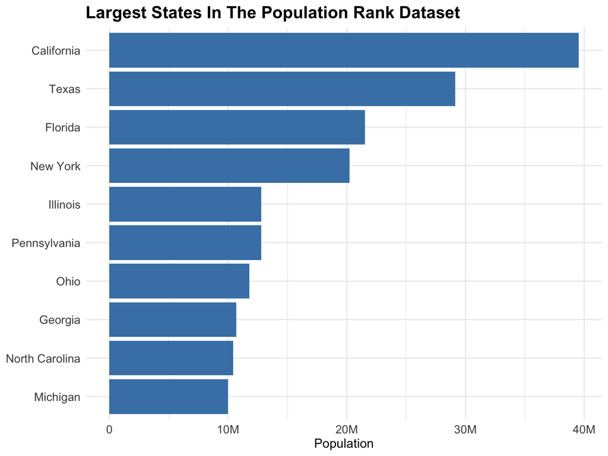

```r
p2 <- p1 +
  theme(
    plot.title = element_text(size = 16, face = "bold"),
    axis.text = element_text(size = 11),
    axis.title = element_text(size = 12)
  )

p2
```

Choose a sensible aspect ratio before you export.

```r
ggsave(
  filename = "practice/work/top-states-just-right.png",
  plot = p2,
  width = 8,
  height = 6,
  dpi = 300,
  bg = "white"
)
```

For manuscripts, it is often cleaner to save final figures in a separate script so every file is exported consistently. Saving as a side effect of a notebook (e.g., putting `ggsave()` in a `.qmd` file) can be fine, but can also be confusing for others trying to figure out how a file was created.

# Takeaways

- Use PNG for most course submissions and slides.
- Use PDF or SVG when vector output matters.
- Choose plot size intentionally, using a sensible, commonly used aspect ratio.